# Part I - (prosperLoanData)

## by (Abdurrahman Muhammad Tukur)

## Introduction

1. Are there differences based on how large the original amount issued as loan is?
2. What are the factors that affect a loan’s outcome status?
3. What affects the borrower’s APR or interest rate?

I will like to define what a prosper loan is;

Prosper loans is a peer-to-peer lending platform that provides personal loans to borrowers with fair or good credit. To qualify applicants, the company uses a proprietary rating system that considers data points like credit history and debt-to-income ratio. Borrowers are then assigned a Prosper score, which investors use to decide whether to fund your loan. [source](https://www.nerdwallet.com/reviews/loans/personal-loans/prosper-personal-loans), To understand more about the column titles you can visit the [google sheet](https://docs.google.com/spreadsheets/d/1gDyi_L4UvIrLTEC6Wri5nbaMmkGmLQBk-Yx3z0XDEtI/edit#gid=0).

## Preliminary Wrangling

```python
# import all packages and set plots to be embedded inline
import numpy as np
import pandas as pd
import matplotlib.pyplot as plt
import seaborn as sb

%matplotlib inline
```

> Load in your dataset and describe its properties through the questions below. Try and motivate your exploration goals through this section.

```python
#Loading my dataset
prosper_loan = pd.read_csv('prosperLoanData.csv')
prosper_loan.head(10)
```

|  | ListingKey | ListingNumber | ListingCreationDate | CreditGrade | Term | LoanStatus | ClosedDate | BorrowerAPR | BorrowerRate | LenderYield | ... | LP_ServiceFees | LP_CollectionFees | LP_GrossPrincipalLoss | LP_NetPrincipalLoss | LP_NonPrincipalRecoverypayments | PercentFunded | Recommendations | InvestmentFromFriendsCount | InvestmentFromFriendsAmount | Investors |
| --- | --- | --- | --- | --- | --- | --- | --- | --- | --- | --- | --- | --- | --- | --- | --- | --- | --- | --- | --- | --- | --- |
| 0 | 1021339766868145413AB3B | 193129 | 2007-08-26 19:09:29.263000000 | C | 36 | Completed | 2009-08-14 00:00:00 | 0.16516 | 0.1580 | 0.1380 | ... | -133.18 | 0.0 | 0.0 | 0.0 | 0.0 | 1.0 | 0 | 0 | 0.0 | 258 |
| 1 | 10273602499503308B223C1 | 1209647 | 2014-02-27 08:28:07.900000000 | NaN | 36 | Current | NaN | 0.12016 | 0.0920 | 0.0820 | ... | 0.00 | 0.0 | 0.0 | 0.0 | 0.0 | 1.0 | 0 | 0 | 0.0 | 1 |
| 2 | 0EE9337825851032864889A | 81716 | 2007-01-05 15:00:47.090000000 | HR | 36 | Completed | 2009-12-17 00:00:00 | 0.28269 | 0.2750 | 0.2400 | ... | -24.20 | 0.0 | 0.0 | 0.0 | 0.0 | 1.0 | 0 | 0 | 0.0 | 41 |
| 3 | 0EF5356002482715299901A | 658116 | 2012-10-22 11:02:35.010000000 | NaN | 36 | Current | NaN | 0.12528 | 0.0974 | 0.0874 | ... | -108.01 | 0.0 | 0.0 | 0.0 | 0.0 | 1.0 | 0 | 0 | 0.0 | 158 |
| 4 | 0F023589499656230C5E3E2 | 909464 | 2013-09-14 18:38:39.097000000 | NaN | 36 | Current | NaN | 0.24614 | 0.2085 | 0.1985 | ... | -60.27 | 0.0 | 0.0 | 0.0 | 0.0 | 1.0 | 0 | 0 | 0.0 | 20 |
| 5 | 0F05359734824199381F61D | 1074836 | 2013-12-14 08:26:37.093000000 | NaN | 60 | Current | NaN | 0.15425 | 0.1314 | 0.1214 | ... | -25.33 | 0.0 | 0.0 | 0.0 | 0.0 | 1.0 | 0 | 0 | 0.0 | 1 |
| 6 | 0F0A3576754255009D63151 | 750899 | 2013-04-12 09:52:56.147000000 | NaN | 36 | Current | NaN | 0.31032 | 0.2712 | 0.2612 | ... | -22.95 | 0.0 | 0.0 | 0.0 | 0.0 | 1.0 | 0 | 0 | 0.0 | 1 |
| 7 | 0F1035772717087366F9EA7 | 768193 | 2013-05-05 06:49:27.493000000 | NaN | 36 | Current | NaN | 0.23939 | 0.2019 | 0.1919 | ... | -69.21 | 0.0 | 0.0 | 0.0 | 0.0 | 1.0 | 0 | 0 | 0.0 | 1 |
| 8 | 0F043596202561788EA13D5 | 1023355 | 2013-12-02 10:43:39.117000000 | NaN | 36 | Current | NaN | 0.07620 | 0.0629 | 0.0529 | ... | -16.77 | 0.0 | 0.0 | 0.0 | 0.0 | 1.0 | 0 | 0 | 0.0 | 1 |
| 9 | 0F043596202561788EA13D5 | 1023355 | 2013-12-02 10:43:39.117000000 | NaN | 36 | Current | NaN | 0.07620 | 0.0629 | 0.0529 | ... | -16.77 | 0.0 | 0.0 | 0.0 | 0.0 | 1.0 | 0 | 0 | 0.0 | 1 |

10 rows × 81 columns

### What is the structure of your dataset?

> This data set contains 113,937 rows and 81 columns, including ProsperRating (Alpha) , borrower rate (or interest rate), current loan status,loan amount, borrower income...

### What is/are the main feature(s) of interest in your dataset?

> There are many features to work with such as the CreditScore, Original Loan Aount, Monthly Payment, BorrowerAPr, ProsperScore, Borrower Occupation, Borrower State and others, although i selected a few which i felt are neccessary for my visualization and analysis as these features would help in decision making.though from my findings so far my main feature of interest is the BorrowerApr, this is because the BorrowerApr would enable me predict the best feauters the borrowers annual rate for the loan issued.

### What features in the dataset do you think will help support your investigation into your feature(s) of interest?

> I think that Employment Status and Stated Monthly income will play a vital role in the amount of loan given and the Term given to the borrowers, and i also think that loan status will also have an impact on loan, there are so many interest columns that will help my investigation as i carry on my analysis so it wont come as a surprise that while running my analysis i might pick up some new variables of interest.

```python
prosper_loan.shape
```

```
(113937, 81)
```

```python
#Overview of the dataset
prosper_loan.info()
```

```
<class 'pandas.core.frame.DataFrame'>
RangeIndex: 113937 entries, 0 to 113936
Data columns (total 81 columns):
 #   Column                               Non-Null Count   Dtype
---  ------                               --------------   -----
 0   ListingKey                           113937 non-null  object
 1   ListingNumber                        113937 non-null  int64
 2   ListingCreationDate                  113937 non-null  object
 3   CreditGrade                          28953 non-null   object
 4   Term                                 113937 non-null  int64
 5   LoanStatus                           113937 non-null  object
 6   ClosedDate                           55089 non-null   object
 7   BorrowerAPR                          113912 non-null  float64
 8   BorrowerRate                         113937 non-null  float64
 9   LenderYield                          113937 non-null  float64
```

[output cut: 73 more lines]

```python
#making duplicate copy of the data
prosper_loan_copy = prosper_loan.copy()
```

```python
prosper_loan.isnull().sum()
```

```
ListingKey                         0
ListingNumber                      0
ListingCreationDate                0
CreditGrade                    84984
Term                               0
                               ...
PercentFunded                      0
Recommendations                    0
InvestmentFromFriendsCount         0
InvestmentFromFriendsAmount        0
Investors                          0
Length: 81, dtype: int64
```

looking to the above codecell displays the missing values of this dataset here we can clearly see that the data entry for the `Credit Grade` has about 84984 missing values.

```python
prosper_loan.shape
```

```
(113937, 81)
```

```python
prosper_loan.describe()
```

|  | ListingNumber | Term | BorrowerAPR | BorrowerRate | LenderYield | EstimatedEffectiveYield | EstimatedLoss | EstimatedReturn | ProsperRating (numeric) | ProsperScore | ... | LP_ServiceFees | LP_CollectionFees | LP_GrossPrincipalLoss | LP_NetPrincipalLoss | LP_NonPrincipalRecoverypayments | PercentFunded | Recommendations | InvestmentFromFriendsCount | InvestmentFromFriendsAmount | Investors |
| --- | --- | --- | --- | --- | --- | --- | --- | --- | --- | --- | --- | --- | --- | --- | --- | --- | --- | --- | --- | --- | --- |
| count | 1.139370e+05 | 113937.000000 | 113912.000000 | 113937.000000 | 113937.000000 | 84853.000000 | 84853.000000 | 84853.000000 | 84853.000000 | 84853.000000 | ... | 113937.000000 | 113937.000000 | 113937.000000 | 113937.000000 | 113937.000000 | 113937.000000 | 113937.000000 | 113937.000000 | 113937.000000 | 113937.000000 |
| mean | 6.278857e+05 | 40.830248 | 0.218828 | 0.192764 | 0.182701 | 0.168661 | 0.080306 | 0.096068 | 4.072243 | 5.950067 | ... | -54.725641 | -14.242698 | 700.446342 | 681.420499 | 25.142686 | 0.998584 | 0.048027 | 0.023460 | 16.550751 | 80.475228 |
| std | 3.280762e+05 | 10.436212 | 0.080364 | 0.074818 | 0.074516 | 0.068467 | 0.046764 | 0.030403 | 1.673227 | 2.376501 | ... | 60.675425 | 109.232758 | 2388.513831 | 2357.167068 | 275.657937 | 0.017919 | 0.332353 | 0.232412 | 294.545422 | 103.239020 |
| min | 4.000000e+00 | 12.000000 | 0.006530 | 0.000000 | -0.010000 | -0.182700 | 0.004900 | -0.182700 | 1.000000 | 1.000000 | ... | -664.870000 | -9274.750000 | -94.200000 | -954.550000 | 0.000000 | 0.700000 | 0.000000 | 0.000000 | 0.000000 | 1.000000 |
| 25% | 4.009190e+05 | 36.000000 | 0.156290 | 0.134000 | 0.124200 | 0.115670 | 0.042400 | 0.074080 | 3.000000 | 4.000000 | ... | -73.180000 | 0.000000 | 0.000000 | 0.000000 | 0.000000 | 1.000000 | 0.000000 | 0.000000 | 0.000000 | 2.000000 |
| 50% | 6.005540e+05 | 36.000000 | 0.209760 | 0.184000 | 0.173000 | 0.161500 | 0.072400 | 0.091700 | 4.000000 | 6.000000 | ... | -34.440000 | 0.000000 | 0.000000 | 0.000000 | 0.000000 | 1.000000 | 0.000000 | 0.000000 | 0.000000 | 44.000000 |
| 75% | 8.926340e+05 | 36.000000 | 0.283810 | 0.250000 | 0.240000 | 0.224300 | 0.112000 | 0.116600 | 5.000000 | 8.000000 | ... | -13.920000 | 0.000000 | 0.000000 | 0.000000 | 0.000000 | 1.000000 | 0.000000 | 0.000000 | 0.000000 | 115.000000 |
| max | 1.255725e+06 | 60.000000 | 0.512290 | 0.497500 | 0.492500 | 0.319900 | 0.366000 | 0.283700 | 7.000000 | 11.000000 | ... | 32.060000 | 0.000000 | 25000.000000 | 25000.000000 | 21117.900000 | 1.012500 | 39.000000 | 33.000000 | 25000.000000 | 1189.000000 |

8 rows × 61 columns

```python
prosper_loan_copy.head()
```

|  | ListingKey | ListingNumber | ListingCreationDate | CreditGrade | Term | LoanStatus | ClosedDate | BorrowerAPR | BorrowerRate | LenderYield | ... | LP_ServiceFees | LP_CollectionFees | LP_GrossPrincipalLoss | LP_NetPrincipalLoss | LP_NonPrincipalRecoverypayments | PercentFunded | Recommendations | InvestmentFromFriendsCount | InvestmentFromFriendsAmount | Investors |
| --- | --- | --- | --- | --- | --- | --- | --- | --- | --- | --- | --- | --- | --- | --- | --- | --- | --- | --- | --- | --- | --- |
| 0 | 1021339766868145413AB3B | 193129 | 2007-08-26 19:09:29.263000000 | C | 36 | Completed | 2009-08-14 00:00:00 | 0.16516 | 0.1580 | 0.1380 | ... | -133.18 | 0.0 | 0.0 | 0.0 | 0.0 | 1.0 | 0 | 0 | 0.0 | 258 |
| 1 | 10273602499503308B223C1 | 1209647 | 2014-02-27 08:28:07.900000000 | NaN | 36 | Current | NaN | 0.12016 | 0.0920 | 0.0820 | ... | 0.00 | 0.0 | 0.0 | 0.0 | 0.0 | 1.0 | 0 | 0 | 0.0 | 1 |
| 2 | 0EE9337825851032864889A | 81716 | 2007-01-05 15:00:47.090000000 | HR | 36 | Completed | 2009-12-17 00:00:00 | 0.28269 | 0.2750 | 0.2400 | ... | -24.20 | 0.0 | 0.0 | 0.0 | 0.0 | 1.0 | 0 | 0 | 0.0 | 41 |
| 3 | 0EF5356002482715299901A | 658116 | 2012-10-22 11:02:35.010000000 | NaN | 36 | Current | NaN | 0.12528 | 0.0974 | 0.0874 | ... | -108.01 | 0.0 | 0.0 | 0.0 | 0.0 | 1.0 | 0 | 0 | 0.0 | 158 |
| 4 | 0F023589499656230C5E3E2 | 909464 | 2013-09-14 18:38:39.097000000 | NaN | 36 | Current | NaN | 0.24614 | 0.2085 | 0.1985 | ... | -60.27 | 0.0 | 0.0 | 0.0 | 0.0 | 1.0 | 0 | 0 | 0.0 | 20 |

5 rows × 81 columns

i call the copy of the data i made for further analysis so that changes might not affect the entire dataset

```python
dropped_col = prosper_loan_copy.iloc[:, [4,2,6,7,8,9,14,15,47,16,17,18,19,36,59,63,64,67,71,80,5,21,13]]

dropped_col
```

|  | Term | ListingCreationDate | ClosedDate | BorrowerAPR | BorrowerRate | LenderYield | ProsperRating (Alpha) | ProsperScore | IncomeRange | ListingCategory (numeric) | ... | AmountDelinquent | LoanCurrentDaysDelinquent | LoanOriginalAmount | LoanOriginationDate | MonthlyLoanPayment | LP_ServiceFees | Investors | LoanStatus | IsBorrowerHomeowner | ProsperRating (numeric) |
| --- | --- | --- | --- | --- | --- | --- | --- | --- | --- | --- | --- | --- | --- | --- | --- | --- | --- | --- | --- | --- | --- |
| 0 | 36 | 2007-08-26 19:09:29.263000000 | 2009-08-14 00:00:00 | 0.16516 | 0.1580 | 0.1380 | NaN | NaN | $25,000-49,999 | 0 | ... | 472.0 | 0 | 9425 | 2007-09-12 00:00:00 | 330.43 | -133.18 | 258 | Completed | True | NaN |
| 1 | 36 | 2014-02-27 08:28:07.900000000 | NaN | 0.12016 | 0.0920 | 0.0820 | A | 7.0 | $50,000-74,999 | 2 | ... | 0.0 | 0 | 10000 | 2014-03-03 00:00:00 | 318.93 | 0.00 | 1 | Current | False | 6.0 |
| 2 | 36 | 2007-01-05 15:00:47.090000000 | 2009-12-17 00:00:00 | 0.28269 | 0.2750 | 0.2400 | NaN | NaN | Not displayed | 0 | ... | NaN | 0 | 3001 | 2007-01-17 00:00:00 | 123.32 | -24.20 | 41 | Completed | False | NaN |
| 3 | 36 | 2012-10-22 11:02:35.010000000 | NaN | 0.12528 | 0.0974 | 0.0874 | A | 9.0 | $25,000-49,999 | 16 | ... | 10056.0 | 0 | 10000 | 2012-11-01 00:00:00 | 321.45 | -108.01 | 158 | Current | True | 6.0 |
| 4 | 36 | 2013-09-14 18:38:39.097000000 | NaN | 0.24614 | 0.2085 | 0.1985 | D | 4.0 | $100,000+ | 2 | ... | 0.0 | 0 | 15000 | 2013-09-20 00:00:00 | 563.97 | -60.27 | 20 | Current | True | 3.0 |
| ... | ... | ... | ... | ... | ... | ... | ... | ... | ... | ... | ... | ... | ... | ... | ... | ... | ... | ... | ... | ... | ... |
| 113932 | 36 | 2013-04-14 05:55:02.663000000 | NaN | 0.22354 | 0.1864 | 0.1764 | C | 5.0 | $50,000-74,999 | 1 | ... | 0.0 | 0 | 10000 | 2013-04-22 00:00:00 | 364.74 | -75.58 | 1 | Current | True | 4.0 |
| 113933 | 36 | 2011-11-03 20:42:55.333000000 | NaN | 0.13220 | 0.1110 | 0.1010 | A | 8.0 | $75,000-99,999 | 7 | ... | 5062.0 | 0 | 2000 | 2011-11-07 00:00:00 | 65.57 | -30.05 | 22 | FinalPaymentInProgress | True | 6.0 |
| 113934 | 60 | 2013-12-13 05:49:12.703000000 | NaN | 0.23984 | 0.2150 | 0.2050 | D | 3.0 | $25,000-49,999 | 1 | ... | 0.0 | 0 | 10000 | 2013-12-23 00:00:00 | 273.35 | -16.91 | 119 | Current | True | 3.0 |
| 113935 | 60 | 2011-11-14 13:18:26.597000000 | 2013-08-13 00:00:00 | 0.28408 | 0.2605 | 0.2505 | C | 5.0 | $25,000-49,999 | 2 | ... | 0.0 | 0 | 15000 | 2011-11-21 00:00:00 | 449.55 | -235.05 | 274 | Completed | True | 4.0 |
| 113936 | 36 | 2014-01-15 09:27:37.657000000 | NaN | 0.13189 | 0.1039 | 0.0939 | A | 7.0 | $50,000-74,999 | 1 | ... | 257.0 | 0 | 2000 | 2014-01-21 00:00:00 | 64.90 | -1.70 | 1 | Current | False | 6.0 |

113937 rows × 23 columns

The codecell above shows the select the columns by index

```python
dropped_col.columns
```

```
Index(['Term', 'ListingCreationDate', 'ClosedDate', 'BorrowerAPR',
       'BorrowerRate', 'LenderYield', 'ProsperRating (Alpha)', 'ProsperScore',
       'IncomeRange', 'ListingCategory (numeric)', 'BorrowerState',
       'Occupation', 'EmploymentStatus', 'AmountDelinquent',
       'LoanCurrentDaysDelinquent', 'LoanOriginalAmount',
       'LoanOriginationDate', 'MonthlyLoanPayment', 'LP_ServiceFees',
       'Investors', 'LoanStatus', 'IsBorrowerHomeowner',
       'ProsperRating (numeric)'],
      dtype='object')
```

```python
dropped_col.info()
```

```
<class 'pandas.core.frame.DataFrame'>
RangeIndex: 113937 entries, 0 to 113936
Data columns (total 23 columns):
 #   Column                     Non-Null Count   Dtype
---  ------                     --------------   -----
 0   Term                       113937 non-null  int64
 1   ListingCreationDate        113937 non-null  object
 2   ClosedDate                 55089 non-null   object
 3   BorrowerAPR                113912 non-null  float64
 4   BorrowerRate               113937 non-null  float64
 5   LenderYield                113937 non-null  float64
 6   ProsperRating (Alpha)      84853 non-null   object
 7   ProsperScore               84853 non-null   float64
 8   IncomeRange                113937 non-null  object
 9   ListingCategory (numeric)  113937 non-null  int64
 10  BorrowerState              108422 non-null  object
 11  Occupation                 110349 non-null  object
 12  EmploymentStatus           111682 non-null  object
 13  AmountDelinquent           106315 non-null  float64
 14  LoanCurrentDaysDelinquent  113937 non-null  int64
 15  LoanOriginalAmount         113937 non-null  int64
 16  LoanOriginationDate        113937 non-null  object
 17  MonthlyLoanPayment         113937 non-null  float64
 18  LP_ServiceFees             113937 non-null  float64
 19  Investors                  113937 non-null  int64
 20  LoanStatus                 113937 non-null  object
 21  IsBorrowerHomeowner        113937 non-null  bool
 22  ProsperRating (numeric)    84853 non-null   float64
dtypes: bool(1), float64(8), int64(5), object(9)
memory usage: 19.2+ MB
```

```python
dropped_col.duplicated()
```

```
0         False
1         False
2         False
3         False
4         False
          ...
113932    False
113933    False
113934    False
113935    False
113936    False
Length: 113937, dtype: bool
```

looks like there is duplicates in the dataset

```python
dropped_col.isnull().sum()
```

```
Term                             0
ListingCreationDate              0
ClosedDate                   58848
BorrowerAPR                     25
BorrowerRate                     0
LenderYield                      0
ProsperRating (Alpha)        29084
ProsperScore                 29084
IncomeRange                      0
ListingCategory (numeric)        0
BorrowerState                 5515
Occupation                    3588
EmploymentStatus              2255
AmountDelinquent              7622
LoanCurrentDaysDelinquent        0
LoanOriginalAmount               0
LoanOriginationDate              0
MonthlyLoanPayment               0
LP_ServiceFees                   0
Investors                        0
LoanStatus                       0
IsBorrowerHomeowner              0
ProsperRating (numeric)      29084
dtype: int64
```

```python
dropped_col.dropna(inplace = True)
dropped_col.shape
```

```
(25992, 23)
```

```python
dropped_col.ClosedDate
```

```
15        2012-12-19 00:00:00
23        2013-12-26 00:00:00
26        2013-10-22 00:00:00
27        2013-07-03 00:00:00
30        2012-12-19 00:00:00
                 ...
113908    2011-01-31 00:00:00
113913    2013-05-05 00:00:00
113928    2011-09-19 00:00:00
113929    2014-02-07 00:00:00
113935    2013-08-13 00:00:00
Name: ClosedDate, Length: 25992, dtype: object
```

```python
# converting the Dtypes of the selected columns to be categorical
dropped_col[['Occupation', 'EmploymentStatus','LoanStatus',
          'ListingCategory (numeric)']].apply(lambda x: x.astype('category'))
```

|  | Occupation | EmploymentStatus | LoanStatus | ListingCategory (numeric) |
| --- | --- | --- | --- | --- |
| 15 | Other | Other | Defaulted | 13 |
| 23 | Skilled Labor | Employed | Defaulted | 15 |
| 26 | Sales - Commission | Employed | Completed | 1 |
| 27 | Executive | Full-time | Completed | 1 |
| 30 | Other | Employed | Completed | 20 |
| ... | ... | ... | ... | ... |
| 113908 | Sales - Commission | Employed | Completed | 3 |
| 113913 | Analyst | Full-time | Completed | 1 |
| 113928 | Other | Full-time | Completed | 3 |
| 113929 | Accountant/CPA | Employed | Completed | 2 |
| 113935 | Food Service | Full-time | Completed | 2 |

25992 rows × 4 columns

## Univariate Exploration

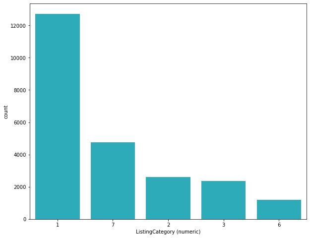

```python
plt.figure(figsize =[10,8])
list_category = dropped_col['ListingCategory (numeric)'].value_counts()[:5]
feature  = list_category.index
base_color = sb.color_palette()[9]
sb.countplot(data = dropped_col, x = 'ListingCategory (numeric)', order = feature, color = base_color)
```

## Insight

- As we see above majority of the people have taken the loan for debt consolidation.

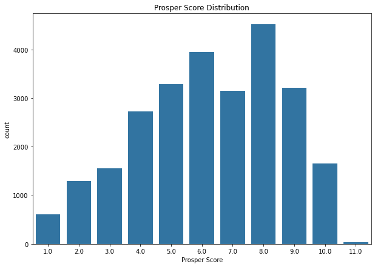

```python
#plotting the Prosper Score Distributions
base_color = sb.color_palette()[0]
plt.figure(figsize=[10, 7])
sb.countplot(data = dropped_col, x= 'ProsperScore', color=base_color)
plt.title('Prosper Score Distribution')
plt.xlabel('Prosper Score');
```

**Insight**

```python
# lets look at the percentage of people with various occupation in this dataset
occpt_list = dropped_col["Occupation"].value_counts()[:5]
occpt_index = occpt_list.index
```

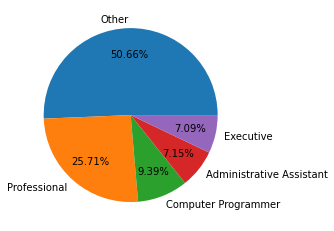

```python
plt.pie(occpt_list, labels= occpt_index,pctdistance= 0.7 , autopct = "%.2f%%");
```

**insight**

- it appears that people categorized under the `Other` column seem to have the highest value count.

```python
# Finding out the count for the employment status of customers who were granted loan
loan_count = dropped_col['EmploymentStatus'].value_counts().rename_axis('sub_employment_values').reset_index(name = 'counts')
loan_count.head(5)
```

|  | sub_employment_values | counts |
| --- | --- | --- |
| 0 | Employed | 16479 |
| 1 | Full-time | 6530 |
| 2 | Self-employed | 1330 |
| 3 | Other | 785 |
| 4 | Not employed | 375 |

```python
total_of_counts = loan_count.counts.sum()
total_of_counts
```

```
25992
```

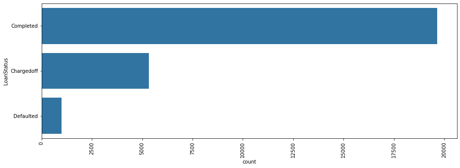

```python
# taking count of LoanStatus

list_category = dropped_col['LoanStatus'].value_counts()[:5]
feature  = list_category.index

plt.figure(figsize=[15,5])
sb.countplot(data = dropped_col, y = "LoanStatus", order=feature, color= base_color)
plt.xticks(rotation = 90);
```

**Insight**

```python
def autopct_format(percent_value):
    """this function will help to format the percenrtage of the categorical variable in one decimal place"""
    return'{:.1f}%\n{:.0f}'.format(percent_value, total_of_counts*percent_value/100)
```

```python
first_label = loan_count.sub_employment_values
label_values = loan_count.counts
```

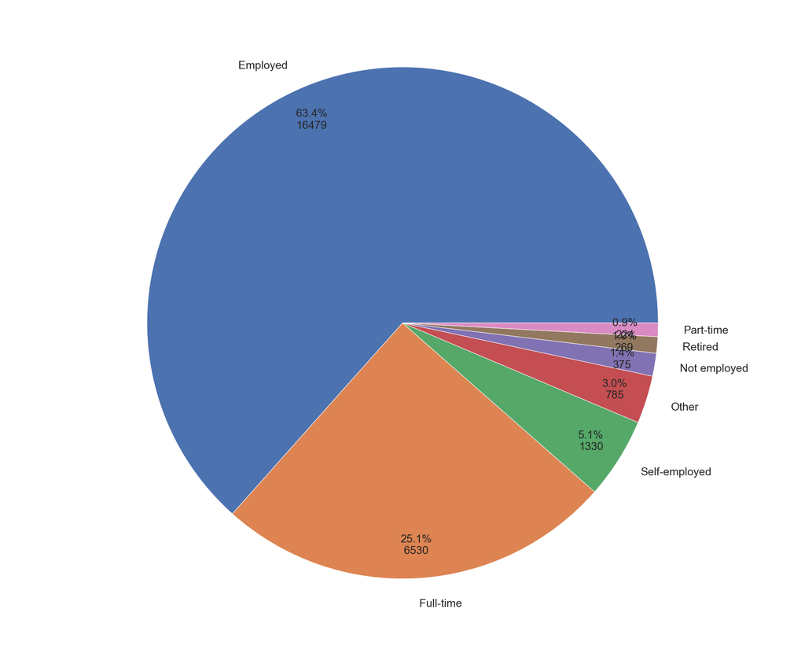

```python
fig = plt.figure(figsize=[25,20])
ax = fig.add_axes([0,0,1,1])
ax.axis('equal')
ax.pie(label_values, labels = first_label, autopct = autopct_format, pctdistance= 0.87, textprops = {'fontsize': 25});
plt.show();
```

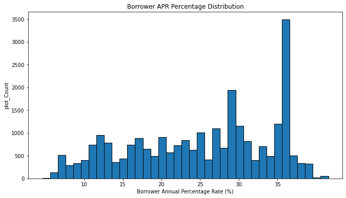

```python
# Borrowe Apr percentage Distribution
borrower_APR_percentage = dropped_col['BorrowerAPR']*100
bins = np.arange(dropped_col['BorrowerAPR'].min()*100, dropped_col['BorrowerAPR'].max()*100)

plt.figure(figsize=[11, 6])
plt.hist(x = borrower_APR_percentage, bins = bins, edgecolor = 'black')
plt.title('Borrower APR Percentage Distribution')
plt.xlabel('Borrower Annual Percentage Rate (%)')
plt.ylabel('plot_Count')
plt.xticks([10,15,20,25,30, 35], ['10', '15', '20', '25', '30', '35'])
plt.show()
```

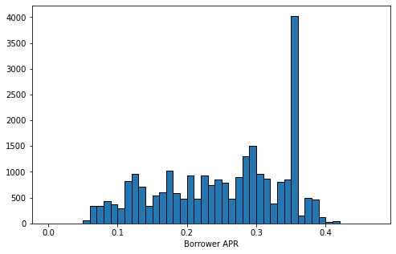

```python
# To further understand the distribution of BorrowerApr
bins = np.arange(0, dropped_col.BorrowerAPR.max()+0.05, 0.01)
plt.figure(figsize=[8, 5])
plt.hist(data = dropped_col, x = 'BorrowerAPR', bins = bins, edgecolor = 'black');
plt.xlabel('Borrower APR');
```

**Insight**

```python
dropped_col['BorrowerAPR'][dropped_col['BorrowerAPR']>= 0.43].value_counts()
```

```
Series([], Name: BorrowerAPR, dtype: int64)
```

```python
dropped_col['ProsperRating (Alpha)'].value_counts().index
```

```
Index(['D', 'E', 'C', 'HR', 'A', 'B', 'AA'], dtype='object')
```

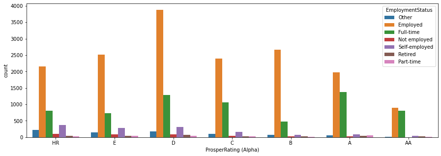

```python
plt.figure(figsize = [15, 5])
ordered_rating = ['HR','E','D','C','B','A','AA']
ordered_var = pd.api.types.CategoricalDtype(ordered = True,
                                    categories = ordered_rating)
dropped_col['ProsperRating (Alpha)'] = dropped_col['ProsperRating (Alpha)'].astype(ordered_var)

sb.countplot(x = 'ProsperRating (Alpha)', hue = 'EmploymentStatus', data = dropped_col)
```

**Insight**

- the above plot clearly shows that lower ratings are associated with the sample population that fall under the categories of the following employment status `Not employed, Self employed, Retired and Part time.` i think this also explains why the small range of values in my previous plot fell under the category of people who didnt have certain details. The ratings are mostly categorized.

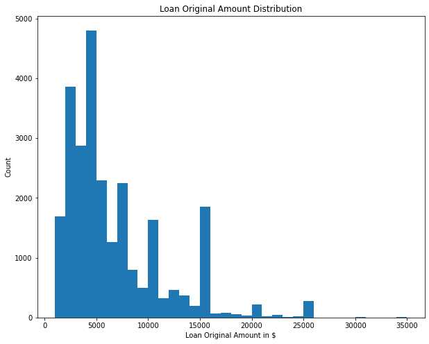

```python
binsize = 1000
bins = np.arange(dropped_col['LoanOriginalAmount'].min(), dropped_col['LoanOriginalAmount'].max()+binsize, binsize)

plt.figure(figsize=[10, 8])
plt.hist(data = dropped_col, x = 'LoanOriginalAmount', bins = bins)
plt.title('Loan Original Amount Distribution')
plt.xlabel('Loan Original Amount in $')
plt.ylabel('Count')
plt.show()
```

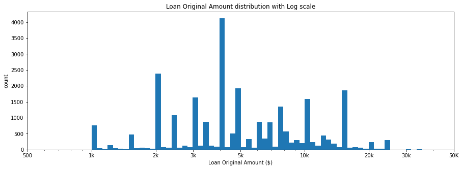

```python
# Putting Loan Original Amount on a log-scale
log_binsize = 0.025
bins = 10 ** np.arange(3, np.log10(dropped_col['LoanOriginalAmount'].max())+log_binsize, log_binsize)

plt.figure(figsize=[15, 5])
plt.hist(data = dropped_col, x = 'LoanOriginalAmount', bins = bins)
plt.title('Loan Original Amount distribution with Log scale')
plt.xscale('log')
plt.xticks([500, 1e3, 2e3,3e3, 5e3, 1e4, 2e4, 3e4, 5e4], ['500', '1k', '2k', '3k', '5k', '10k', '20k', '30k', '50K'])
plt.xlabel('Loan Original Amount ($)')
plt.ylabel('count')
plt.show()
```

**Insight** The highest value is between 3k and 5k, that should roughly be a `4.` and there is also a pick between 10k and 20k.

```python
# Using a function to carry out the countplot
loan_ft = ['EmploymentStatus', 'ProsperRating (Alpha)', 'ProsperScore','ListingCategory (numeric)',
           'Occupation', 'ListingCreationDate', 'LoanOriginalAmount', 'Investors', 'LoanStatus']
```

```python
list(enumerate(loan_ft)) #To return the list of columns and there corresponding index
```

```
[(0, 'EmploymentStatus'),
 (1, 'ProsperRating (Alpha)'),
 (2, 'ProsperScore'),
 (3, 'ListingCategory (numeric)'),
 (4, 'Occupation'),
 (5, 'ListingCreationDate'),
 (6, 'LoanOriginalAmount'),
 (7, 'Investors'),
 (8, 'LoanStatus')]
```

```python
# Checking the values of the column Term.
dropped_col.Term.value_counts()
```

```
36    20765
60     3696
12     1531
Name: Term, dtype: int64
```

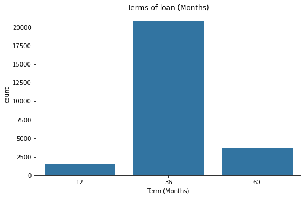

```python
# creating a frequency distribution of the Term (variable)
plt.figure(figsize = [8,5])
base_color = sb.color_palette()[0]
sb.countplot(data = dropped_col,x= 'Term',color=base_color);
plt.title('Terms of loan (Months)')
plt.xlabel('Term (Months)');
```

**Insight**

```python
sb.color_palette()[9]
```

```
(0.09019607843137255, 0.7450980392156863, 0.8117647058823529)
```

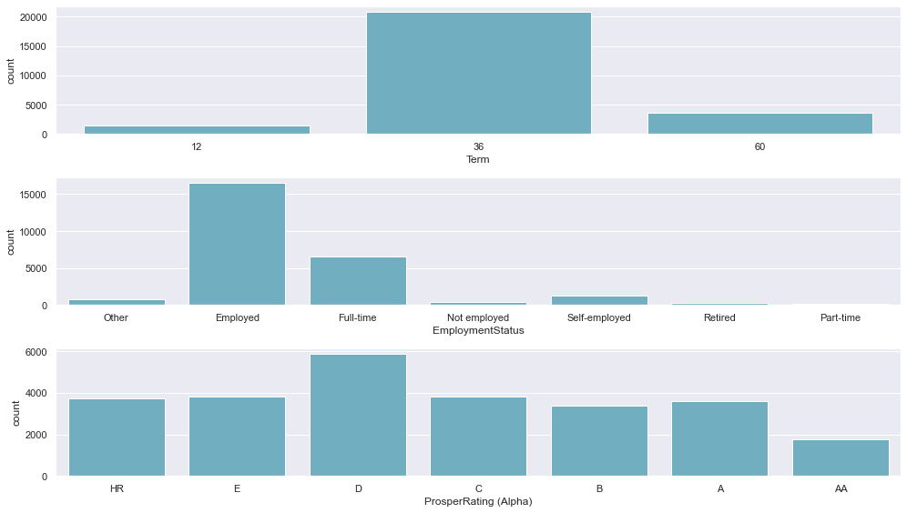

```python
# Plotting the three variables to understand the ordinal variable distribution

fig, ax = plt.subplots(nrows = 3, figsize = [14,8])
sb_color = sb.color_palette()[9]
sb.countplot(x = 'Term', data = dropped_col, color = sb_color, ax = ax[0])
sb.countplot(x = 'EmploymentStatus', data = dropped_col, color = sb_color, ax = ax[1])
sb.countplot(x = 'ProsperRating (Alpha)', data = dropped_col, color = sb_color, ax = ax[2]);
plt.xticks(rotation =0);
plt.tight_layout()
```

**Insight**

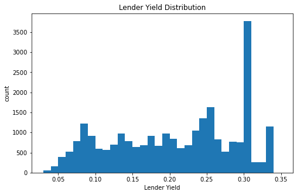

```python
#Lender Yield Distribution
binsize = 0.01
bins = np.arange(dropped_col['LenderYield'].min(), dropped_col['LenderYield'].max()+binsize, binsize)

plt.figure(figsize=[8, 5])
plt.hist(data = dropped_col, x = 'LenderYield', bins = bins)
plt.xlabel('Lender Yield')
plt.title('Lender Yield Distribution')
plt.ylabel('count');
```

**Insight**

```python
dropped_col.info()
```

```
<class 'pandas.core.frame.DataFrame'>
Int64Index: 25992 entries, 15 to 113935
Data columns (total 23 columns):
 #   Column                     Non-Null Count  Dtype
---  ------                     --------------  -----
 0   Term                       25992 non-null  int64
 1   ListingCreationDate        25992 non-null  object
 2   ClosedDate                 25992 non-null  object
 3   BorrowerAPR                25992 non-null  float64
 4   BorrowerRate               25992 non-null  float64
 5   LenderYield                25992 non-null  float64
 6   ProsperRating (Alpha)      25992 non-null  category
 7   ProsperScore               25992 non-null  float64
 8   IncomeRange                25992 non-null  object
 9   ListingCategory (numeric)  25992 non-null  int64
 10  BorrowerState              25992 non-null  object
 11  Occupation                 25992 non-null  object
 12  EmploymentStatus           25992 non-null  object
 13  AmountDelinquent           25992 non-null  float64
 14  LoanCurrentDaysDelinquent  25992 non-null  int64
 15  LoanOriginalAmount         25992 non-null  int64
 16  LoanOriginationDate        25992 non-null  object
 17  MonthlyLoanPayment         25992 non-null  float64
 18  LP_ServiceFees             25992 non-null  float64
 19  Investors                  25992 non-null  int64
 20  LoanStatus                 25992 non-null  object
 21  IsBorrowerHomeowner        25992 non-null  bool
 22  ProsperRating (numeric)    25992 non-null  float64
dtypes: bool(1), category(1), float64(8), int64(5), object(8)
memory usage: 5.4+ MB
```

```python
dropped_col['AmountDelinquent'].max()
```

```
327677.0
```

```python
dropped_col['AmountDelinquent'].min()
```

```
0.0
```

```python
dropped_col['AmountDelinquent'].value_counts()
```

```
0.0        22294
50.0          23
100.0         23
25.0          16
75.0          15
           ...
53148.0        1
721.0          1
122.0          1
667.0          1
3742.0         1
Name: AmountDelinquent, Length: 2398, dtype: int64
```

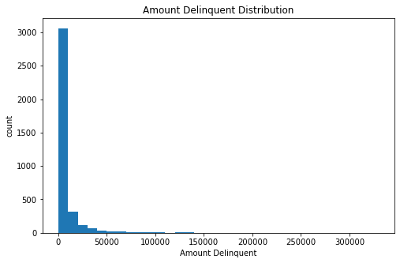

```python
#Amount Delinquent Distribution
binsize = 10000
bins = np.arange(dropped_col['AmountDelinquent'].min(), dropped_col['AmountDelinquent'].max()+binsize, binsize)

plt.figure(figsize=[8, 5])
plt.hist(data = dropped_col[dropped_col['AmountDelinquent']>0], x = 'AmountDelinquent', bins = bins)
plt.title('Amount Delinquent Distribution')
plt.xlabel('Amount Delinquent')
plt.ylabel('count')
plt.show()
```

**Insight**

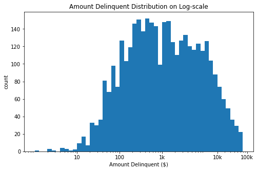

```python
log_binsize = 0.1
bins = 10 ** np.arange(0,5, log_binsize)

plt.figure(figsize=[8, 5])
plt.hist(data = dropped_col, x = 'AmountDelinquent', bins = bins)
plt.title('Amount Delinquent Distribution on Log-scale')
plt.xscale('log')
plt.xticks([1e1, 1e2, 1e3, 2e4, 1e5], ['10', '100', '1k', '10k', '100k'])
plt.xlabel('Amount Delinquent ($)')
plt.ylabel('count')
plt.show()
```

**Insight**

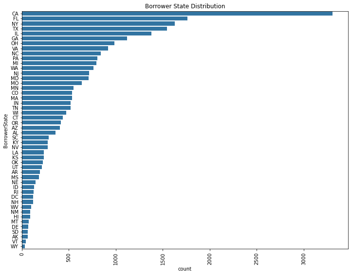

```python
#BorrowerState Distrobution
ordered_cat = dropped_col['BorrowerState'].value_counts().index
plt.figure(figsize=[12, 9])
sb.countplot(data = dropped_col,y='BorrowerState',color=base_color, order=ordered_cat);
plt.title('Borrower State Distribution');
plt.xticks(rotation=90);
```

**Insight**

### Discuss the distribution(s) of your variable(s) of interest. Were there any unusual points? Did you need to perform any transformations?

Carlifona has the highest number of loans, the loan terms of this dataset is mostly within 36months and one thing that really picked my interst was that people who borrowed the most were either employed or full time and just like i said could this be a factor of a higher standard of living knowing that you always receive salary, but that would be an analysis done on a different dataset.

## Bivariate Exploration

> in other to investigate relationships i would categorize my data variables into various sections namely:
> - Numeric or Quantitative
> - Categorical or Qualitative this is because Bivariate exploration deals with these two variuable types.

#### Using the same variable name `dropped_col`

```python
dropped_col.info()
```

```
<class 'pandas.core.frame.DataFrame'>
Int64Index: 25992 entries, 15 to 113935
Data columns (total 23 columns):
 #   Column                     Non-Null Count  Dtype
---  ------                     --------------  -----
 0   Term                       25992 non-null  int64
 1   ListingCreationDate        25992 non-null  object
 2   ClosedDate                 25992 non-null  object
 3   BorrowerAPR                25992 non-null  float64
 4   BorrowerRate               25992 non-null  float64
 5   LenderYield                25992 non-null  float64
 6   ProsperRating (Alpha)      25992 non-null  category
 7   ProsperScore               25992 non-null  float64
 8   IncomeRange                25992 non-null  object
 9   ListingCategory (numeric)  25992 non-null  int64
 10  BorrowerState              25992 non-null  object
 11  Occupation                 25992 non-null  object
 12  EmploymentStatus           25992 non-null  object
 13  AmountDelinquent           25992 non-null  float64
 14  LoanCurrentDaysDelinquent  25992 non-null  int64
 15  LoanOriginalAmount         25992 non-null  int64
 16  LoanOriginationDate        25992 non-null  object
 17  MonthlyLoanPayment         25992 non-null  float64
 18  LP_ServiceFees             25992 non-null  float64
 19  Investors                  25992 non-null  int64
 20  LoanStatus                 25992 non-null  object
 21  IsBorrowerHomeowner        25992 non-null  bool
 22  ProsperRating (numeric)    25992 non-null  float64
dtypes: bool(1), category(1), float64(8), int64(5), object(8)
memory usage: 5.4+ MB
```

```python
# Selecting the varibles for both Qualitative and Quantitative data types

categorical_variables = ['ProsperRating (Alpha)','IncomeRange', 'ListingCategory (numeric)', 'BorrowerState', 'Occupation',
                         'EmploymentStatus', 'LoanStatus']

numeric_variables = ['Term', 'BorrowerAPR', 'BorrowerRate', 'LenderYield', 'ProsperScore', 'MonthlyLoanPayment',
                     'Investors','AmountDelinquent','LoanCurrentDaysDelinquent','LoanOriginalAmount','LP_ServiceFees']
```

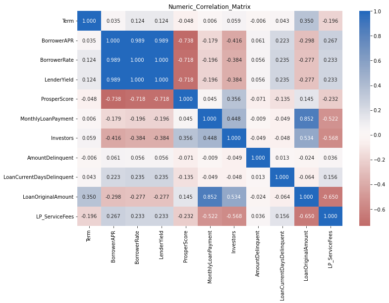

```python
# Creating a correlation matrix for all numeric variables.
plt.figure(figsize = [12, 8])
sb.heatmap(dropped_col[numeric_variables].corr(), annot = True, fmt = '.3f',
           cmap = 'vlag_r', center = 0)
plt.title('Numeric_Correlation_Matrix')
plt.show()
```

**Insight**

- one interesting thing to note is that, aside being in a positive relationship with each other`(the columns)`, there is acutally a positive relationship between the columns like **LoanOriginationAmount and MonthlyLoanPayment, and also BorrowerApr and BorrowerRate amongst others**

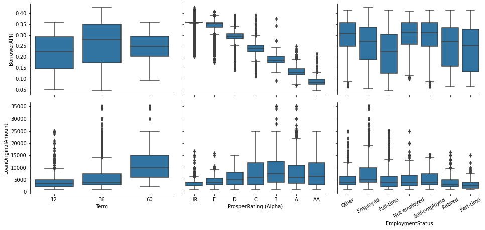

```python
CtL_dtypes = ['LoanOriginalAmount', 'BorrowerAPR',]
Qlt_dtypes = ['Term', 'ProsperRating (Alpha)', 'EmploymentStatus']


def boxgrid(x, y, **kwargs):
    default_color = sb.color_palette()[0]
    sb.boxplot(x, y, color = default_color)

plt.figure(figsize = [10, 10])
g = sb.PairGrid(data = dropped_col, y_vars= ['BorrowerAPR', 'LoanOriginalAmount'],
                x_vars = Qlt_dtypes, height = 3, aspect = 1.5);
g.map(boxgrid);
plt.xticks(rotation=30);
```

**Insight**

- The plot above shows the BorrowerApr decreases with the rating and that the loan amount has an increase with the loarn term, Borrowers who have the best rating (AA) also have the lowest BorrowerAPr which is intiutively relatable, i mean if you are known to pay on time you will obviously be rated highly, this means that the ProsperRating also has a strong effect on BorrowerApr.

```python
# Plotting a matrix, since we will plot the matrix rather than plotting scatter plots one by one

dropped_col_stats = ['Term', 'BorrowerAPR', 'BorrowerRate','ProsperScore','MonthlyLoanPayment','AmountDelinquent','LoanOriginalAmount']
```

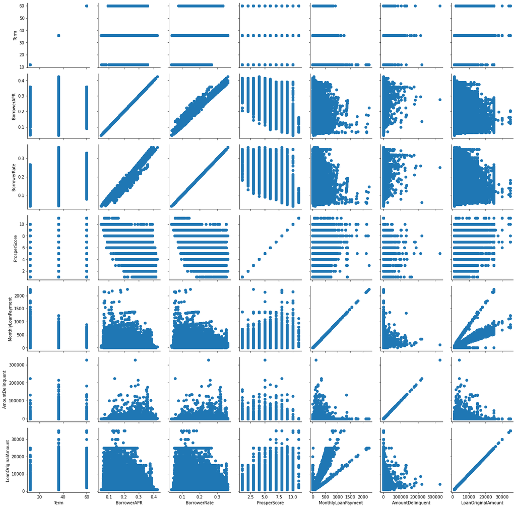

```python
g= sb.PairGrid(data = dropped_col, vars = dropped_col_stats);
g.map(plt.scatter)
```

**Insight**

- There is a positive relationship between LenderYeild and BorrowerApr also BorrowerRAte. ProsperRAting and ProsperScore also have a positive relationship, this doesnt come as a surprise to me because during the other plots these two variables played a significant rule in letting me know why loans were given to certain persons.
- There also is a negative relationship between ProsperScore and BorrowerApr, and Lender Yeild. *sidenote* A little limitation here with studying the variables for insight as the image is too large.*

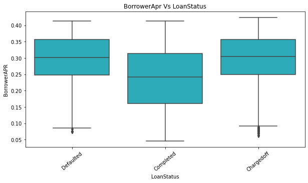

```python
# plot against BorrowerApr and Loan Status

color = sb.color_palette()[9]
plt.figure(figsize = (10,5))
sb.boxplot(x ='LoanStatus', y= 'BorrowerAPR',  data = dropped_col, color = color);
plt.title('BorrowerApr Vs LoanStatus')
plt.xticks(rotation = 40);
```

**Insight**

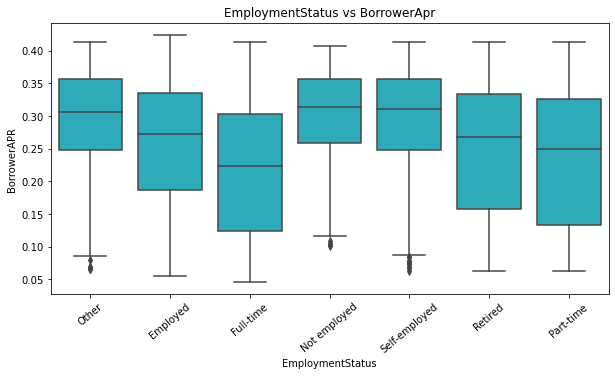

```python
# plot against EmploymentStatus and BorrowerApr

color = sb.color_palette()[9]
plt.figure(figsize = (10,5))
sb.boxplot(x ='EmploymentStatus', y= 'BorrowerAPR',  data = dropped_col, color = color);
plt.title('EmploymentStatus vs BorrowerApr')
plt.xticks(rotation = 40);
```

**insight**

```python
dropped_col['ListingCategory (numeric)'].value_counts().index[14]
```

```
10
```

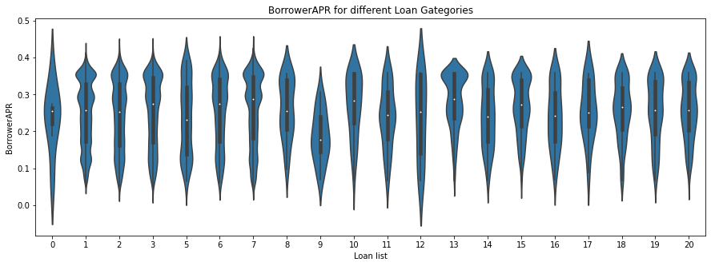

```python
# Lets try to understand what is going on in the variables BorrowerApr and the listingCategory
plt.figure(figsize = [15, 5])
sb.violinplot(data = dropped_col,x='ListingCategory (numeric)', y='BorrowerAPR',color=base_color);
plt.title('BorrowerAPR for different Loan Gategories')
plt.xlabel('Loan list');
plt.ylabel('BorrowerAPR');
```

**Insight**

```python
fav_color= sb.color_palette()[0]
```

```python
# Defining a funtion to be able to plot a violinplot to understand the relationship between variables and look at the distribution of data
def func_violin(dropped_col, var1 , var2 ):
    " this is how to plot a function that will help you reduce the no of times you write code"
    sb.violinplot(data = dropped_col, x =var1, y =  var2, color = fav_color )
    plt.xticks(rotation = 360)
```

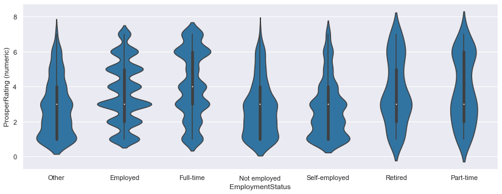

```python
plt.figure(figsize=[14,5])
func_violin(dropped_col, 'EmploymentStatus','ProsperRating (numeric)' )
```

**Insight**

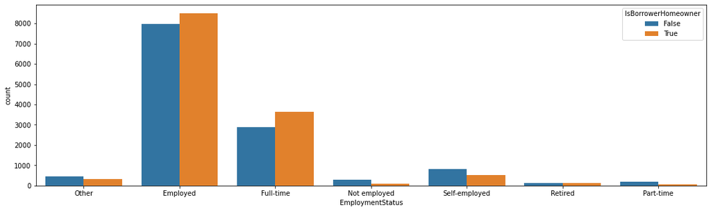

```python
# lets see how many people own houses in this dataset
plt.figure(figsize=[18,5])
sb.countplot (data = dropped_col, x = "EmploymentStatus" , hue ="IsBorrowerHomeowner")
```

**Insight**

### Talk about some of the relationships you observed in this part of the investigation. How did the feature(s) of interest vary with other features in the dataset?

> The relationship between the EmploymentStatus and BorrowerAPr show that people who unemployed recieve high interest rate compared to the employed which i said would be because it will be easier to think that employed persons will pay up better than those for are unemployed, the higher the income of the person the lower the interest rate.

## Multivariate Exploration

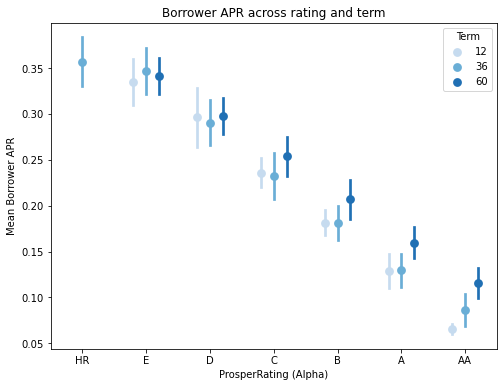

```python
fig = plt.figure(figsize = [8,6])
ax = sb.pointplot(data = dropped_col, x = 'ProsperRating (Alpha)', y = 'BorrowerAPR', hue = 'Term',
           palette = 'Blues', linestyles = '', dodge = 0.4, ci='sd')
plt.title('Borrower APR across rating and term')
plt.ylabel('Mean Borrower APR')
ax.set_yticklabels([],minor = True);
```

**Insight**

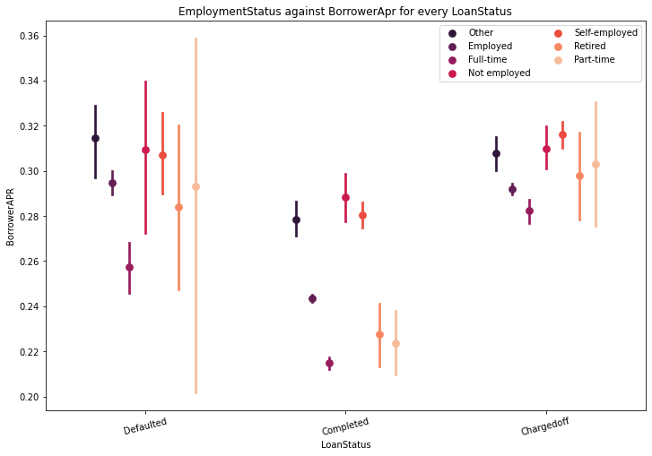

```python
# Plotting EmploymentStatus against BorrowerApr for every LoanStatus

plt.figure(figsize = [12,8])
ax = sb.pointplot(x= 'LoanStatus', y= 'BorrowerAPR', hue = 'EmploymentStatus', data = dropped_col, linestyles = '', dodge = 0.5,
                  palette ='rocket' )
plt.title('EmploymentStatus against BorrowerApr for every LoanStatus')
plt.ylabel('BorrowerAPR')
plt.legend(ncol=2)
plt.xticks(rotation = 14);
```

**Insight**

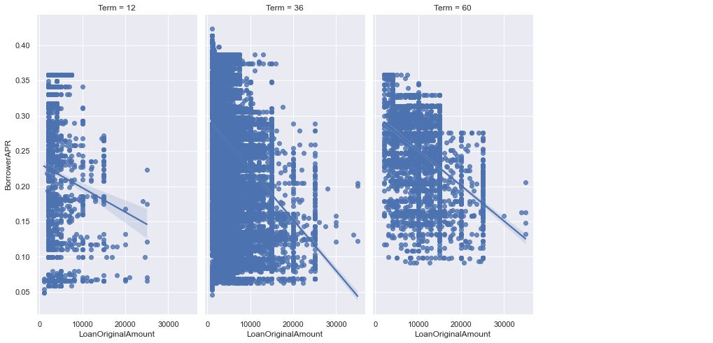

```python
# The effect of Term on BorrowerApr and Loan amount
g=sb.FacetGrid(data = dropped_col, aspect=1.2, height=4, col='Term', col_wrap=4)
g.map(sb.regplot, 'LoanOriginalAmount', 'BorrowerAPR')
g.add_legend();
g.fig.set_size_inches(14, 8);
```

**Insight**

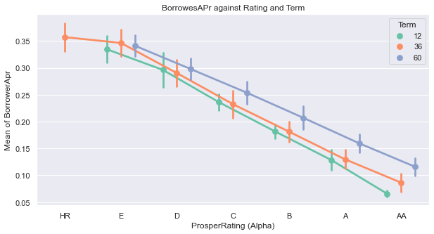

```python
# Plotting BorrowersAprs against Rating Term
plt.figure(figsize=[10,5])
sb.set_theme(style="darkgrid")

sb.pointplot(x ='ProsperRating (Alpha)', y ='BorrowerAPR', hue = 'Term', data = dropped_col, palette = 'Set2', linestyle ='',
             dodge = 0.5, ci ='sd')
plt.title('BorrowesAPr against Rating and Term')
plt.ylabel('Mean of BorrowerApr');
```

**Insight**

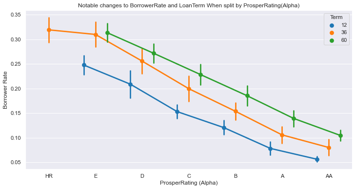

```python
plt.figure(figsize=[12,6])

sb.pointplot(x ='ProsperRating (Alpha)', y ='BorrowerRate', hue = 'Term', data = dropped_col, palette = 'tab10', linestyle ='',
             dodge = 0.5, ci ='sd')
plt.title('Notable changes to BorrowerRate and LoanTerm When split by ProsperRating(Alpha)')
plt.ylabel('Borrower Rate');
```

```python
dropped_col.EmploymentStatus.value_counts()
dropped_col.Occupation.value_counts()
```

```
Other                          6756
Professional                   3429
Computer Programmer            1252
Administrative Assistant        954
Executive                       946
                               ...
Dentist                          10
Student - College Freshman       10
Student - Community College       6
Judge                             2
Student - Technical School        1
Name: Occupation, Length: 67, dtype: int64
```

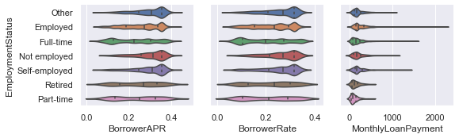

```python
plt.figure(figsize=[20,5])
g = sb.PairGrid(data = dropped_col, x_vars =['BorrowerAPR', 'BorrowerRate','MonthlyLoanPayment'],
                y_vars = ['EmploymentStatus'])
g.map(sb.violinplot, inner = 'quartile');
```

**Insight**

Like horizontal bar charts, horizontal violin plots are ideal for dealing with many categories. Swapping axes gives the category labels more room to breathe.

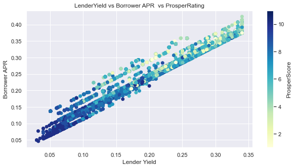

```python
# LenderYield vs Borrower APR  vs ProsperRating
plt.figure(figsize = [10, 5])
plt.scatter(data = dropped_col,x='LenderYield',y = 'BorrowerAPR',c='ProsperScore',cmap = 'YlGnBu')
plt.colorbar(label = 'ProsperScore');
plt.title('LenderYield vs Borrower APR  vs ProsperRating');
plt.xlabel('Lender Yield');
plt.ylabel('Borrower APR');
```

**Insight**

- Here it is very clear that the plot depicts a positive relationship between the 2 variables `BorrowerApr and LenderYield`, this correlation shows that when the borrowers of the loan pays, the lenderyield increases but the higher the prosper score the lower the borrowerapr and lenderyield.

### Talk about some of the relationships you observed in this part of the investigation. Were there features that strengthened each other in terms of looking at your feature(s) of interest?

> My exploration led me to to understand that BorrowerApr and LenderYield both have a positive relationship and influence the prosperscore, they strengthened each other in the sense that when borrowers pay up it increase their prosper score, it quite interesting because an ordinary example will be that if i was to borrower someone money and got paid back without hestitation it would definitely build trust, now put that in the place of the prosperscore and it all sums up.

## Conclusions

This is by a long shot the best task I assume I have dealt with, I have been generating plots yet haven't perceived the profundity of investigation as of recently, there is this feeling of understanding that accompanies recognizing factors and knowing what to plot and how to plot them into the classes of Univariate, Bivariate and Multivariate and these are the means taking to go through the investigation, you should initially distinguish the factors, then comprehend the significance to the dataset which I did by utilizing the google sheet and researching about the ProsperLoan, what they do and how they order each piece of information, afterwords comprehending what plot is essential as I referenced before and afterward take a gander at your plot to comprehend what is going on with the numbers.

> My limit generally remains in regards to deficient power supply and a touch of delaying as I would have wrapped up some time back, I recently continued to search for new plots to take a stab at and I likewise realized that there is more work to be finished in the future in light of the fact that to me it appears to be the more I learn the more I figure out that I was ignorant earlier on.

> To end this in outline I would recognize my guide **MR ROTIMI KOLAWOLE** who is a phenomenal coach, his assistance with explaining subtleties and separating them into little crumps enables me to gain confidence in drawing up my insights.